# Forecasting Methods - Final Project

#### Cross Validation

Let’s test each model for cross-validation forecast for each iteration and compare. Here, several combinations have been tested, including linear or logistic and changepoint_range. Here, holidays have also been included.

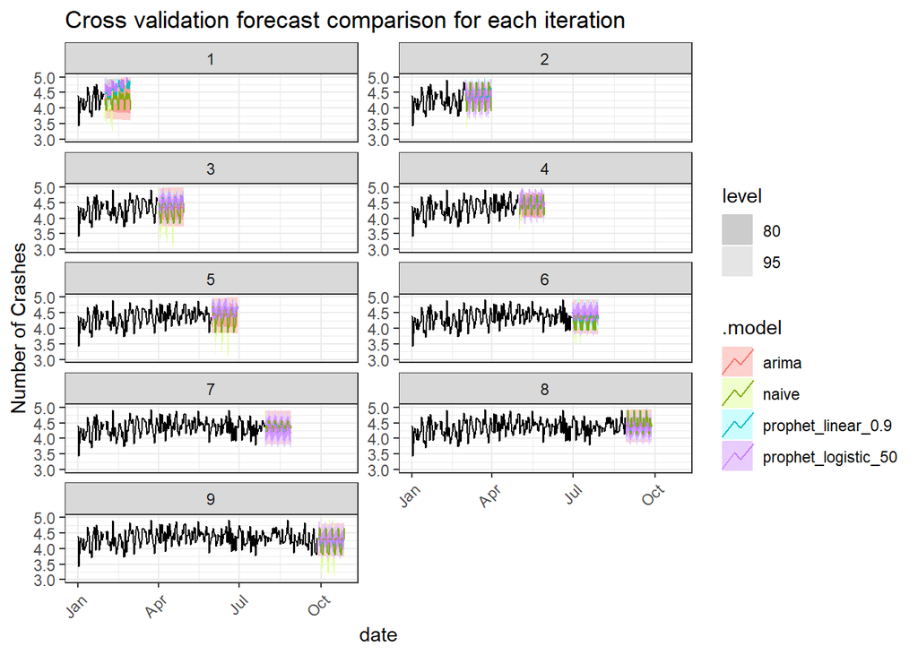

```r
accidents_cv_forecast <- accidents_cv %>%
  model(
    naive = SNAIVE(accidents_log~lag('week')),

    arima = ARIMA(accidents_log ~ pdq(0,1,2)+ PDQ(0,0,0)),

  prophet_logistic_50 = fable.prophet::prophet(accidents_log~growth(type="logistic",n_changepoints=50,capacity=750,floor=0)+season(period='week',type='additive')+holiday(final_holidays)),


  prophet_linear_0.9= fable.prophet::prophet(accidents_log~growth(type= "linear",changepoint_range=0.9,capacity=750,floor=0)+season(period='week',type='additive')+holiday(final_holidays)),


  ) %>%
  forecast(h = 30)


accidents_cv_forecast %>%
  autoplot(accidents_cv) +
  facet_wrap(~.id,ncol=2, scales = 'free_y') +
  theme_bw() +
  ylab('Number of Crashes') + ggtitle("Cross validation forecast comparison for each iteration") +  # Using month abbreviations as labels
  theme(axis.text.x = element_text(angle = 45, hjust = 1))+
  ylim(3,5)
```

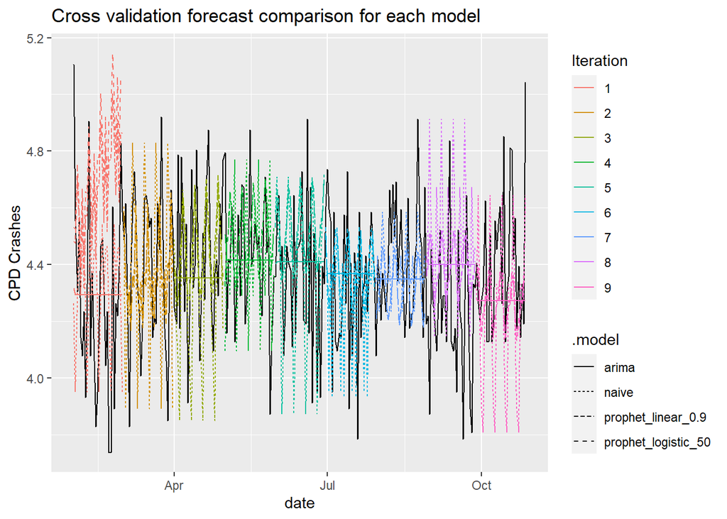

```r
accidents_cv_forecast %>%
  as_tibble() %>%
  select(-accidents_log) %>%
  left_join(
      accidents_tsbl
  ) %>%

    ggplot()+
    geom_line(aes(date,accidents_log))+
    geom_line(aes(date,.mean,color=factor(.id),linetype=.model))+
    scale_color_discrete(name='Iteration')+
    ylab('CPD Crashes')+ ggtitle("Cross validation forecast comparison for each model")
```

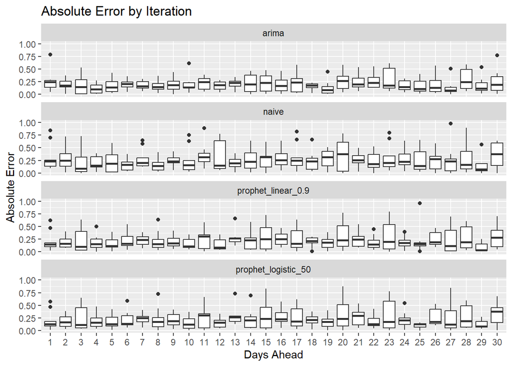

```r
accidents_cv_forecast %>%
  as_tibble() %>%
  select(-accidents_log) %>%
  left_join(accidents_tsbl) %>%
  group_by(.id,.model) %>%
  mutate(
    days_ahead = seq(1:30)
  ) %>%
  ungroup() %>%
  filter(days_ahead<=30) %>%
  mutate(error = abs(accidents_log - .mean)) %>%
  ggplot()+
  geom_boxplot(aes(factor(days_ahead),error))+
  facet_wrap(~.model,ncol=1)+
  guides(color='none')+
  ylab('Absolute Error')+
  xlab('Days Ahead')+
  ggtitle('Absolute Error by Iteration')+
  ylim(0,1)
```

#### Comparison of models using RMSE, MAPE and MAE

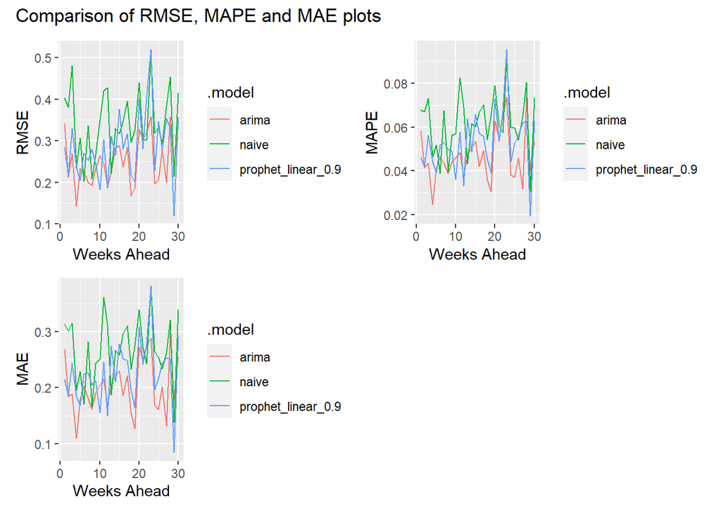

```r
rmse = accidents_cv_forecast %>%
  as_tibble() %>%
  select(-accidents_log) %>%
  left_join(accidents_tsbl) %>%
  group_by(.id,.model) %>%
  mutate(
    weeks_ahead = seq(1:30)
  ) %>%
  ungroup() %>%
  filter(!is.na(accidents_log)) %>%
  group_by(weeks_ahead,.model) %>%
  summarize(
    rmse = sqrt(mean((accidents_log - .mean)^2,na.rm=T)),
  ) %>%
  ungroup() %>%
  filter(.model != "prophet_logistic_50") %>%
  ggplot()+
  geom_line(aes(weeks_ahead,rmse,color=.model))+
  xlab("Weeks Ahead")+
  ylab("RMSE")

mape = accidents_cv_forecast %>%
  as_tibble() %>%
  select(-accidents_log) %>%
  left_join(accidents_tsbl) %>%
  group_by(.id,.model) %>%
  mutate(
    weeks_ahead = seq(1:30)
  ) %>%
  ungroup() %>%
  group_by(weeks_ahead,.model) %>%
  mutate(
    mape = mean(abs((accidents_log - .mean)/accidents_log),na.rm=T)
  ) %>%
  ungroup() %>%
  filter(.model != "prophet_logistic_50") %>%
  ggplot()+
  geom_line(aes(weeks_ahead,mape,color=.model))+
  xlab("Weeks Ahead")+
  ylab("MAPE")

mae = accidents_cv_forecast %>%
  as_tibble() %>%
  select(-accidents_log) %>%
  left_join(accidents_tsbl) %>%
  group_by(.id, .model) %>%
  mutate(weeks_ahead = seq(1:30)) %>%
  ungroup() %>%
  group_by(weeks_ahead, .model) %>%
  mutate(mae = mean(abs(accidents_log - .mean), na.rm = TRUE)) %>%
  ungroup() %>%
  filter(.model != "prophet_logistic_50") %>%
  ggplot() +
  geom_line(aes(weeks_ahead, mae, color = .model)) +
  xlab("Weeks Ahead") +
  ylab("MAE")

rmse+mape+mae+plot_layout(ncol = 2, byrow = TRUE) + plot_annotation(title = "Comparison of RMSE, MAPE and MAE plots")
```

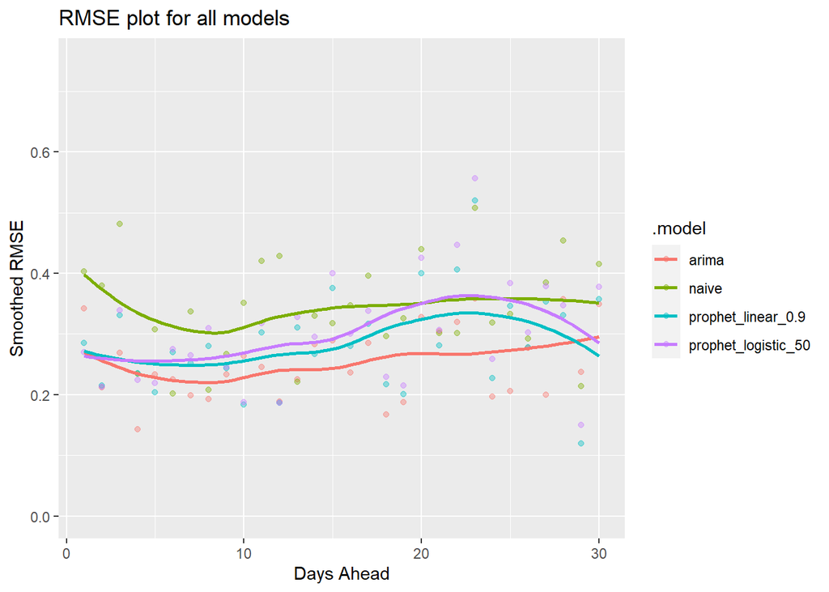

```r
accidents_cv_forecast %>%
  as_tibble() %>%
  select(-accidents_log) %>%
  left_join(accidents_tsbl) %>%
  group_by(.id,.model) %>%
  mutate(
    days_ahead = seq(1:30)
  ) %>%
  ungroup() %>%
  filter(!is.na(accidents_log)) %>%
  group_by(days_ahead,.model) %>%
  summarize(
    rmse = sqrt(mean((accidents_log - .mean)^2,na.rm=T)),
  ) %>%
  ungroup() %>%
  ggplot()+
  geom_point(aes(days_ahead,rmse,color=.model),alpha=0.4)+
  geom_smooth(aes(days_ahead,rmse,color=.model),se=F)+
  xlab("Days Ahead")+
  ylab("Smoothed RMSE")+
  ylim(0,0.75) +
  labs(title = 'RMSE plot for all models')
```

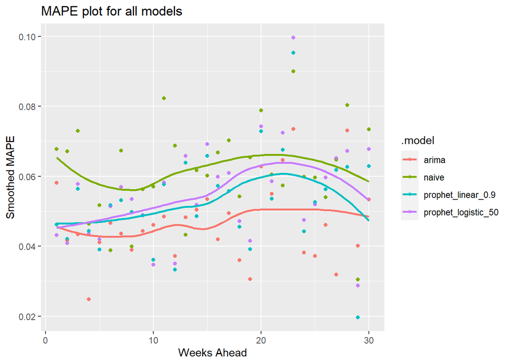

```r
accidents_cv_forecast %>%
  as_tibble() %>%
  select(-accidents_log) %>%
  left_join(accidents_tsbl) %>%
  group_by(.id,.model) %>%
  mutate(
    days_ahead = seq(1:30)
  ) %>%
  ungroup() %>%
  group_by(days_ahead,.model) %>%
  mutate(
    mape = mean(abs((accidents_log - .mean)/accidents_log),na.rm=T)
  ) %>%
  ungroup() %>%
  ggplot()+
  geom_point(aes(days_ahead,mape,color=.model),alpha=0.4)+
  geom_smooth(aes(days_ahead,mape,color=.model),se=F)+
  xlab("Weeks Ahead")+
  ylab("Smoothed MAPE")+
  labs(title = 'MAPE plot for all models')
```

Based on the above RMSE, MAPE plots, we can clearly see that our ARIMA model performs the best. We can also observe that our prophet model performs slightly better than a seasonal naive model. Now, let’s fit our best selected model on the test set and discuss the performance results.

#### Fitting final model and forecasting

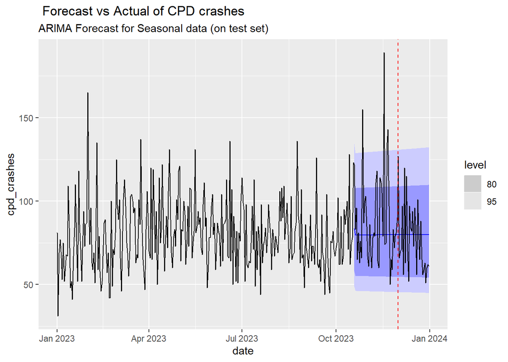

```r
best_model_arima %>%
 forecast(h=74) %>%
 autoplot(
 train %>%
 as_tsibble() %>%
 select(date,cpd_crashes) %>%
 bind_rows(
 test %>%
 as_tsibble() %>%
 select(date,cpd_crashes)
 )) +
 geom_vline(aes(xintercept = ymd("2023-12-01")), color = "red", linetype = "dashed") +
 ggtitle(" Forecast vs Actual of CPD crashes", subtitle = 'ARIMA Forecast for Seasonal data (on test set)')
```

```r
best_model_arima %>%
    forecast(h=73) %>%
    accuracy(test)
```

```
# A tibble: 1 × 10
  .model .type    ME  RMSE   MAE   MPE  MAPE  MASE RMSSE   ACF1
  <chr>  <chr> <dbl> <dbl> <dbl> <dbl> <dbl> <dbl> <dbl>  <dbl>
1 mod1   Test   4.14  26.1  19.0 -2.69  21.8   NaN   NaN 0.0732
```

Now, let’s fit the best model to entire data and produce a forecast for a meaningful period of time.

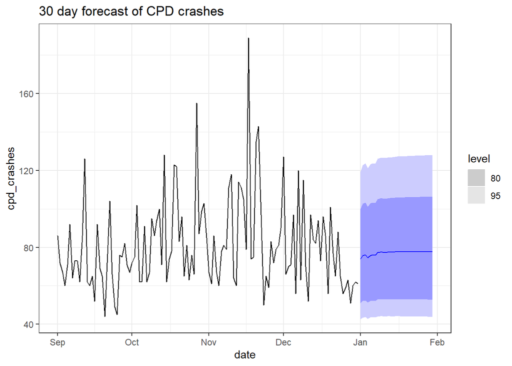

```r
accidents_tsbl %>%
  model(
    ARIMA(log(cpd_crashes) ~ pdq(0,1,2),approximation=F)) %>%

  forecast(h=30) %>%
  autoplot(
    accidents_tsbl %>%
    filter(date>=ymd('2023-09-01'))
  )+
  theme_bw() + ggtitle("30 day forecast of CPD crashes")
```

The forecast has been done for 30 days, and we can see that it is not a very good representation of our data. The forecast tends to constant behaviour, thus maintaining constant variance as expected. However, the model can better include the various fluctuations that are caused in that data. Perhaps, taking into account historical data of at least 3 years would give us better modelling parameters and forecast.